# 03-Discrete-Probability-Calculations

Shaswat Rajput

### **What is Probability ?**

Probability is a branch of mathematics that deals with calculating the likelihood of a given event’s occurrence, which is expressed as a number between 1 and 0. An event with a probability of 1 can be considered a certainty: for example, the probability of a coin toss resulting in either “heads” or “tails” is 1, because there are no other options, assuming the coin lands flat. An event with a probability of .5 can be considered to have equal odds of occurring or not occurring: for example, the probability of a coin toss resulting in “heads” is .5, because the toss is equally as likely to result in “tails.” An event with a probability of 0 can be considered an impossibility: for example, the probability that the coin will land (flat) without either side facing up is 0, because either “heads” or “tails” must be facing up. A little paradoxical, probability theory applies precise calculations to quantify uncertain measures of random events.

**What is a probabilistic model?**  
A probabilistic model is a quantative description of a situation, a phenomenon or an experiment where outcome is uncertain.

#### **Axioms:**

The rules that any probabilistic model should satisfy are called axioms of probability.

**Non-Negativity: P(A) > 0**

Normalisation: P(Ω) = 1

Additivity (Finite) : If two events are disjoint then, P(A ∪ B) = P(A) + P(B)

These 3 axioms are the only requirement in order to have a legitimate probability model.

#### **Role of Probability Theory:**

A Framework for analysing phenomena with uncertain outcomes.

Rule for consistent reasoning.

Used for predictions and decisions.

#### **Discrete Uniform Law:**

Assume Ω consists of n equally likely elements.

Assume A consists of k elements.

So, P(A) = k/n

#### **Probability Calculation Steps:**

Specify the sample space

Specify the probability law

Identify the event of interest

Calculate…

### **Let’s understand about Discrete Probability through following Problem:**

#### **How often does the better team win the World Series?**

The world series is a best-of-7 match-up between the champions of the American and National Leagues of Major League Baseball. In this assignment, you are going to explain probability calculations related to the world series.

##### **Setup:**

Suppose that the Braves and the Yankees are teams competing in the World Series.

Suppose that in any given game, the probability that the Braves win is P<sub>b</sub> and the probability that the Yankees win is P<sub>y</sub> = 1−P<sub>b</sub>.

**1. What is the probability that the Braves win the World Series given that P<sub>b</sub> = 0.55?**

```r
# dbinom(4,7,0.55) + dbinom(5,7,0.55) +dbinom(6,7,0.55) +dbinom(7,7,0.55)
pbinom(3,7,0.55,lower.tail = FALSE)
```

```
## [1] 0.6082878
```

We can say that the probability of Braves winining the world series is —-> P(WS) = P(WS in 4) + P(WS in 5) + P(WS in 6) + P(WS in 7) = 0.608  
We can see that from above code both code works. We can use dbinom to get the specific probability and then we can add it to get the same thing as pbinom with lower.tail=FLASE or pnbinom. In this case we can add the specific probability of happening ie if braves win 4 matches or 5 matches or 6 or 7 matches.

**2. What is the probability that the Braves win the World Series given that P<sub>b</sub> = x? This will be a figure (see below) with PB on the x-axis and P(Braves win World Series) on the y-axis.**

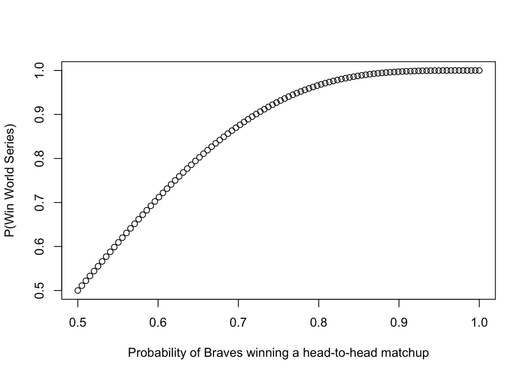

```r
probab <- seq(0.5,1.0, length.out = 100)
win_probab <- rep(NA,100)
for (i in seq_along(probab)){
  win_probab[i] = pbinom(3,7,probab[i],lower.tail = FALSE)
}
plot(probab,win_probab,xlab = "Probability of Braves winning a head-to-head matchup",ylab = "P(Win World Series)")
```

**3. Suppose one could change the World Series to be best-of-9 or some other best-of-X series. What is the shortest series length so that P(Braves win World Series|Psub>b = 0.55) ≥ 0.8 ?** Let’s assume Braves are playing thre best of 11 series. In any given series, a minimum of more than half is required, so in this cade a minimum of 6 wins are required to win the World Series.

```r
ev_od <- function (x) {
  if (x %% 2 == 0) {
    return("even")
  } else {
    return ('odd')
  }
}

for (i in 3:100) {
  if (ev_od(i) == "even") {
    win_probab = pbinom((i / 2), i, 0.55, lower.tail = FALSE)
    if (win_probab >= 0.8) {
      print(i)
      break
    }
  } else if (ev_od(i) == "odd") {
    win_probab = pbinom(floor(i / 2), i, 0.55, lower.tail = FALSE)
    if (win_probab >= 0.8) {
      print(i)
      break
    }
  }
}
```

```
## [1] 71
```

**4. What is the shortest series length so that P(Braves win World Series| P<sub>b</sub> = x) ≥ 0.8? This will be a figure (see below) with P<sub>b</sub> on the x-axis and series length is the y-axis.**

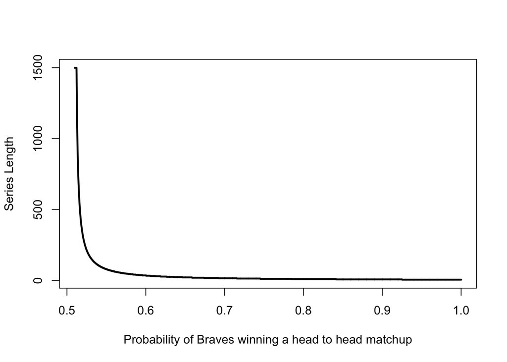

```r
# min_game <- vector()
#
# for (i in 3:100){
#   for (j in seq_along(probab)){
#     if (pbinom(floor(i / 2), i, probab[j], lower.tail = FALSE) >= 0.8){
#       min_game <- c(min_game,i)
#     }
#   }
# }
# plot(x=probab,y=min_game, type = 'l')


p_winning <- function(req_wins,p){
  losses <- req_wins-1
  p_ws <-0

  while (losses >= 0 ){
    p_ws <- p_ws + dbinom(losses, req_wins,p)
    losses = losses-1
  }
  return(p_ws)
}

games <- seq(3,1500,2)
probab_b <- seq(0.51,1.0,0.0001)
min_win <- rep(NA,length(probab_b))

for(i in seq_along(probab_b)){
  for (j in seq_along(games)){
    req_wins <- floor(0.5*games[j]) +1
    probab_B_WS <- p_winning(req_wins = req_wins, probab_b[i])
    if(probab_B_WS >= 0.8){
      break
    }
  }
  min_win[i] <- games[j]
}

plot(y = min_win, x= rev(probab_b), type='l',lwd = 2.5,xlab = "Probability of Braves winning a head to head matchup", ylab = "Series Length")
```

**5. Calculate P(P<sub>b</sub> = 0.55|Braves win World Series in 7 games) under the assumption that either P<sub>b</sub> = 0.55 or P<sub>b</sub> = 0.45. Explain your solution.**

Let’s assume that the P(P<sub>b</sub> = 0.55) and P(P<sub>b</sub> = 0.45) = 0.5, meaning that the events are equally likely.

```r
(0.5 * dnbinom(3,4,0.55)) / ((0.5 * dnbinom(3,4,0.55))+ (0.5 * dnbinom(3,4,0.45)) )
```

```
## [1] 0.55
```

So, P(P<sub>b</sub> = 0.55 | Braves win World Series in 7 games) = P(P<sub>b</sub> = 0.55 ∩ Braves win World Series in 7 games) / P(B)  
OR  
= P(B) * P(Braves win World Series in 7 games | P<sub>b</sub> = 0.55) / ((P(B) * P(Braves win World Series in 7 games | P<sub>b</sub> = 0.55) + (P(B) * P(Braves win World Series in 7 games | P<sub>b</sub> = 0.55)) = 0.55

**References and Further Study:** [Historical Trends in Home-Field Advantage by Cyril Morong](https://web.archive.org/web/20050330200457/http://www.geocities.com/cyrilmorong@sbcglobal.net/HomeRoad.htm)